# Format podatkov

CSV (`sword_results.csv`) iz JSON datotek, ki jih vrne SWORD2. Vrstice se združujejo po proteinih in proteini po particijah.

| stolpec | opis |
| --- | --- |
| protein | PDB koda ter veriga, ki je bila uporabljena za SWORD2 |
| aindex | ambiguity index proteina |
| partition | indeks particije. Optimalna ima 0, alternativne 1 ali več |
| quality | ocena particije |
| domain | indeks domene. Prva domena 1, druga domena 2, … |
| AUL | AUL vrednost domene |
| start | prva aminokislina domene |
| end | zadnja aminokislina domene |

Primer za 1a62_A:

```
protein aindex partition quality domain AUL start end
1a62_A  1      0         0       1      81  1     130 <---| opt.
1a62_A  1      1         1       1      70  1     47 <----| alt. 1
1a62_A  1      1         1       2      0   48    94      |
1a62_A  1      1         1       3      46  95    130     |
1a62_A  1      2         3       1      72  1     47 <----| alt. 2
1a62_A  1      2         3       2      8   48    130     |
1a62_A  1      3         1       1      76  1     130 <---| alt. 3
1a62_A  1      3         1       2      0   48    94      |
```

# Filtriranje glede na sledeče pogoje

1. več kot ena domena v particiji
2. razmerje med katerokoli domeno v particiji naj ne bo večje od 1:2 (največ 1:3)
3. ambiguity index med 1 in 3
4. AUL vrednosti domen vsaj 75 (najmanj 50)

Prvotno je na voljo 1938 proteinov (glej `Groups`).

```r
library(dplyr)
library(ggplot2)

# getwd()
# setwd("..")

# WARN: beri build_decompositions_csv.py za format
csv <- read.csv("sword_results.csv", header = TRUE) |>
    as_tibble() |>
    group_by(protein)
csv
```

```
## # A tibble: 23,263 × 8
## # Groups:   protein [1,938]
##    protein aindex partition quality domain   AUL start   end
##    <chr>    <int>     <int>   <int>  <int> <int> <int> <int>
##  1 1a62_A       1         0       0      1    81     1   130
##  2 1a62_A       1         1       1      1    70     1    47
##  3 1a62_A       1         1       1      2     0    48    94
##  4 1a62_A       1         1       1      3    46    95   130
##  5 1a62_A       1         2       3      1    72     1    47
##  6 1a62_A       1         2       3      2     8    48   130
##  7 1a62_A       1         3       1      1    76     1   130
##  8 1a62_A       1         3       1      2     0    48    94
##  9 1ab1_A       0         0       8      1    79     1    46
## 10 1af7_A       3         0       3      1    56     1    80
## # ℹ 23,253 more rows
```

Uporabil sem **samo optimalne particije.**

## Število Domen

Ostane jih 560 z dvema ali več domenami.

```r
md_opt <- csv |>
    filter(partition == 0) |>
    filter(max(domain) > 1)
md_opt
```

```
## # A tibble: 1,363 × 8
## # Groups:   protein [560]
##    protein aindex partition quality domain   AUL start   end
##    <chr>    <int>     <int>   <int>  <int> <int> <int> <int>
##  1 1af7_A       3         0       3      1    56     1    80
##  2 1af7_A       3         0       3      2    86    81   274
##  3 1c96_A       3         0       4      1    93     1   529
##  4 1c96_A       3         0       4      2    58   530   753
##  5 1d3y_A       3         0       4      1     3     1    74
##  6 1d3y_A       3         0       4      2    85    75   301
##  7 1d3y_B       3         0       4      1     0     1    74
##  8 1d3y_B       3         0       4      2    86    75   301
##  9 1dd3_A       1         0       4      1    83     1    49
## 10 1dd3_A       1         0       4      2    92    50   128
## # ℹ 1,353 more rows
```

```r
table(md_opt$domain)
```

```
##
##   1   2   3   4   5   6   7
## 561 561 171  57   8   4   1
```

## Razmerja med velikostmi domen

```r
prot_group <- function(d, p) {
    d[d$protein == p, ]
}

# razmerje določa cutoff parameter, med 0 in 1
check_ratios <- function(df, cutoff = 0.3) {
    keep <- c()
    for (prot in unique(df$protein)) {
        d2 <- prot_group(df, prot) |> as.data.frame() # tu nočem tibble

        # velikosti domen
        dsizes <- d2$end - d2$start + 1 # ker je 1-based

        # kombinacije vseh domen: (1,2), (1,3), (2,3) ...
        # transponirano, da je dimenzije N×2
        m <- combn(d2$domain, m = 2) |> t()

        # razmerje manjša/večja domena, da je rezultat v intervalu [0,1]
        ratios <- apply(m, 1, \(x) min(dsizes[x]) / max(dsizes[x]))

        # ohrani protein, če so razmerja primerna
        if (all(ratios > cutoff)) {
            keep <- c(keep, prot)
        }
    }
    keep
}
```

```r
# manj strogo
keep03 <- check_ratios(md_opt, cutoff = 0.3)
length(keep03) # koliko jih ostane
```

```
## [1] 432
```

```r
length(unique(md_opt$protein)) - length(keep03) # koliko jih odpade
```

```
## [1] 128
```

```r
md_opt[which(md_opt$protein %in% keep03), ]
```

```
## # A tibble: 982 × 8
## # Groups:   protein [432]
##    protein aindex partition quality domain   AUL start   end
##    <chr>    <int>     <int>   <int>  <int> <int> <int> <int>
##  1 1af7_A       3         0       3      1    56     1    80
##  2 1af7_A       3         0       3      2    86    81   274
##  3 1c96_A       3         0       4      1    93     1   529
##  4 1c96_A       3         0       4      2    58   530   753
##  5 1d3y_A       3         0       4      1     3     1    74
##  6 1d3y_A       3         0       4      2    85    75   301
##  7 1d3y_B       3         0       4      1     0     1    74
##  8 1d3y_B       3         0       4      2    86    75   301
##  9 1dd3_A       1         0       4      1    83     1    49
## 10 1dd3_A       1         0       4      2    92    50   128
## # ℹ 972 more rows
```

```r
# bolj strogo
keep05 <- check_ratios(md_opt, cutoff = 0.5)
length(keep05) # koliko jih ostane
```

```
## [1] 248
```

```r
length(unique(md_opt$protein)) - length(keep05) # koliko jih odpade
```

```
## [1] 312
```

```r
md_opt[which(md_opt$protein %in% keep05), ]
```

```
## # A tibble: 545 × 8
## # Groups:   protein [248]
##    protein aindex partition quality domain   AUL start   end
##    <chr>    <int>     <int>   <int>  <int> <int> <int> <int>
##  1 1dd3_A       1         0       4      1    83     1    49
##  2 1dd3_A       1         0       4      2    92    50   128
##  3 1dd3_B       1         0       4      1    66     1    48
##  4 1dd3_B       1         0       4      2    93    49   128
##  5 1dlj_A       3         0       4      1    88     1   204
##  6 1dlj_A       3         0       4      2    88   205   402
##  7 1dow_A       3         0       5      1    79     1    89
##  8 1dow_A       3         0       5      2    66    90   205
##  9 1dvo_A       2         0       3      1    81     1   152
## 10 1dvo_A       2         0       3      2    74    38   137
## # ℹ 535 more rows
```

Tu sem se odločil ohraniti tiste, katerih razmerja so večja od 1:2. Zaradi tega jih izgubim 184, ki bi jih sicer ohranil, če bi uporabil 1:3.

```r
kept03 <- md_opt[which(md_opt$protein %in% keep03), ]
kept05 <- md_opt[which(md_opt$protein %in% keep05), ]
setdiff(kept03, kept05)
```

```
## # A tibble: 437 × 8
## # Groups:   protein [184]
##    protein aindex partition quality domain   AUL start   end
##    <chr>    <int>     <int>   <int>  <int> <int> <int> <int>
##  1 1af7_A       3         0       3      1    56     1    80
##  2 1af7_A       3         0       3      2    86    81   274
##  3 1c96_A       3         0       4      1    93     1   529
##  4 1c96_A       3         0       4      2    58   530   753
##  5 1d3y_A       3         0       4      1     3     1    74
##  6 1d3y_A       3         0       4      2    85    75   301
##  7 1d3y_B       3         0       4      1     0     1    74
##  8 1d3y_B       3         0       4      2    86    75   301
##  9 1dj0_B       2         0       4      1    89     1   264
## 10 1dj0_B       2         0       4      2    75   113   239
## # ℹ 427 more rows
```

```r
md_keep <- kept05
```

## A-index

```r
md_keep$aindex |> table()
```

```
##
##   1   2   3   4
##  56 144 294  51
```

```r
md_keep <- filter(md_keep, aindex < 4)
md_keep
```

```
## # A tibble: 494 × 8
## # Groups:   protein [235]
##    protein aindex partition quality domain   AUL start   end
##    <chr>    <int>     <int>   <int>  <int> <int> <int> <int>
##  1 1dd3_A       1         0       4      1    83     1    49
##  2 1dd3_A       1         0       4      2    92    50   128
##  3 1dd3_B       1         0       4      1    66     1    48
##  4 1dd3_B       1         0       4      2    93    49   128
##  5 1dlj_A       3         0       4      1    88     1   204
##  6 1dlj_A       3         0       4      2    88   205   402
##  7 1dow_A       3         0       5      1    79     1    89
##  8 1dow_A       3         0       5      2    66    90   205
##  9 1dvo_A       2         0       3      1    81     1   152
## 10 1dvo_A       2         0       3      2    74    38   137
## # ℹ 484 more rows
```

## AUL vrednosti

Vse domene v particiji morajo imeti zadostne/dobre AUL vrednosti. Za zadostne sem uporabil mejo 50, za dobre pa 75.

Vzel sem najslabšo AUL vrednost med domenami v particiji. Če je najslabša večja od meje, potem protein ohranim.

```r
bad_doms <- data.frame()

for (prot in unique(md_keep$protein)) {
    df <- prot_group(md_keep, prot)

    # najdi najslabšo domeno
    bad_dom <- which(df$AUL == min(df$AUL))[1]

    # dodaj na seznam
    bad_doms <- rbind(bad_doms, df[bad_dom, ])
}

bad_doms
```

```
## # A tibble: 235 × 8
## # Groups:   protein [235]
##    protein aindex partition quality domain   AUL start   end
##    <chr>    <int>     <int>   <int>  <int> <int> <int> <int>
##  1 1dd3_A       1         0       4      1    83     1    49
##  2 1dd3_B       1         0       4      1    66     1    48
##  3 1dlj_A       3         0       4      1    88     1   204
##  4 1dow_A       3         0       5      2    66    90   205
##  5 1dvo_A       2         0       3      2    74    38   137
##  6 1dzf_A       2         0       3      2     0   143   215
##  7 1e7l_B       2         0       3      2    83   103   157
##  8 1feh_A       3         0       4      1    38     1   208
##  9 1fn9_A       3         0       4      2    71    94   365
## 10 1fn9_B       3         0       4      1    79     1   336
## # ℹ 225 more rows
```

```r
bad_doms$AUL |> summary()
```

```
##    Min. 1st Qu.  Median    Mean 3rd Qu.    Max.
##    0.00   56.00   74.00   64.69   83.00   93.00
```

```r
# zajame vse proteine
all(group_keys(bad_doms) == group_keys(md_keep))
```

```
## [1] TRUE
```

```r
# ni duplikatov
all(bad_doms$protein == unique(bad_doms$protein))
```

```
## [1] TRUE
```

```
$ magick aul50.png aul75.png aul90.png +append aul_distribution.png
```

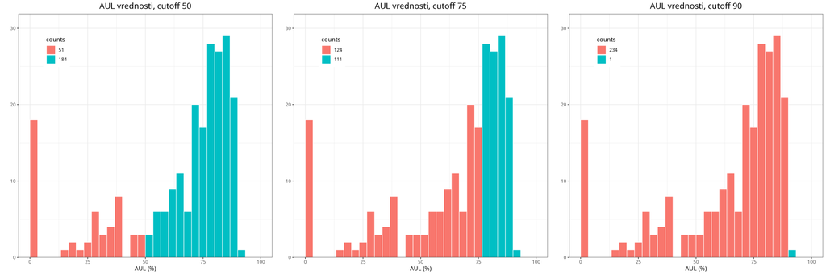

```r
for (c in c(50, 75, 90))
{
    cutoff <- c

    # razdeli na dva dela glede na mejo
    n_below <- sum(bad_doms$AUL <= cutoff)
    n_above <- sum(bad_doms$AUL > cutoff)

    ggplot(bad_doms, aes(x = AUL)) +
        geom_histogram(aes(fill = after_stat(x) > cutoff),
            breaks = seq(0, 100, length.out = 31),
            color = "white",
            linewidth = 0.4
        ) +
        scale_fill_hue(labels = c(n_below, n_above)) +
        scale_y_continuous(expand = expansion(mult = c(0, 0.1))) +
        labs(
            title = paste("AUL vrednosti, cutoff", cutoff),
            x = "AUL (%)",
            y = "",
            fill = "counts"
        ) +
        theme_bw() +
        theme(
            plot.title = element_text(hjust = 0.5, size = 15),
            legend.position = c(0.15, 0.85),
            legend.background = element_rect(fill = "white"),
        )
    ggsave(filename = paste0("aul", cutoff, ".png"))
}
```

Ostane jih 184 z zadostnimi oziroma 111 z dobrimi AUL vrednostmi.

```r
sel <- bad_doms[which(bad_doms$AUL > 75), ]
final05_75 <- filter(md_keep, protein %in% sel$protein)
final05_75
```

```
## # A tibble: 228 × 8
## # Groups:   protein [111]
##    protein aindex partition quality domain   AUL start   end
##    <chr>    <int>     <int>   <int>  <int> <int> <int> <int>
##  1 1dd3_A       1         0       4      1    83     1    49
##  2 1dd3_A       1         0       4      2    92    50   128
##  3 1dlj_A       3         0       4      1    88     1   204
##  4 1dlj_A       3         0       4      2    88   205   402
##  5 1e7l_B       2         0       3      1    84     1   102
##  6 1e7l_B       2         0       3      2    83   103   157
##  7 1fn9_B       3         0       4      1    79     1   336
##  8 1fn9_B       3         0       4      2    83    94   365
##  9 1g38_D       3         0       5      1    84     1   223
## 10 1g38_D       3         0       5      2    83   224   393
## # ℹ 218 more rows
```

```r
write.csv(
    file = "clean_dataset.csv",
    x = final05_75,
    sep = ",",
    quote = FALSE,
    row.names = FALSE
)
```

# Koliko jih odpade zaradi 1:2 pogoja?

```r
md_keep <- kept03
md_keep <- filter(md_keep, aindex < 4)
bad_doms <- data.frame()

for (prot in unique(md_keep$protein)) {
    df <- prot_group(md_keep, prot)
    bad_dom <- which(df$AUL == min(df$AUL))[1]
    bad_doms <- rbind(bad_doms, df[bad_dom, ])
}

sel <- bad_doms[which(bad_doms$AUL > 75), ]
final03_75 <- filter(md_keep, protein %in% sel$protein)

setdiff(final03_75, final05_75)
```

```
## # A tibble: 170 × 8
## # Groups:   protein [76]
##    protein aindex partition quality domain   AUL start   end
##    <chr>    <int>     <int>   <int>  <int> <int> <int> <int>
##  1 1hw1_B       3         0       4      1    77     1    78
##  2 1hw1_B       3         0       4      2    78    79   239
##  3 1hye_A       3         0       3      1    82     1    82
##  4 1hye_A       3         0       3      2    88    83   313
##  5 1jnr_C       3         0       3      1    90     1   643
##  6 1jnr_C       3         0       3      2    81    71   389
##  7 1m15_A       3         0       3      1    84     1    97
##  8 1m15_A       3         0       3      2    93    98   357
##  9 1n7z_B       3         0       4      1    76     1   334
## 10 1n7z_B       3         0       4      2    81    91   236
## # ℹ 160 more rows
```

# Koliko jih odpade zaradi 1:2 in meje 75?

```r
md_keep <- kept03
md_keep <- filter(md_keep, aindex < 4)
bad_doms <- data.frame()

for (prot in unique(md_keep$protein)) {
    df <- prot_group(md_keep, prot)
    bad_dom <- which(df$AUL == min(df$AUL))[1]
    bad_doms <- rbind(bad_doms, df[bad_dom, ])
}

sel <- bad_doms[which(bad_doms$AUL > 50), ]
final03_50 <- filter(md_keep, protein %in% sel$protein)

setdiff(final03_50, final05_75)
```

```
## # A tibble: 449 × 8
## # Groups:   protein [204]
##    protein aindex partition quality domain   AUL start   end
##    <chr>    <int>     <int>   <int>  <int> <int> <int> <int>
##  1 1af7_A       3         0       3      1    56     1    80
##  2 1af7_A       3         0       3      2    86    81   274
##  3 1c96_A       3         0       4      1    93     1   529
##  4 1c96_A       3         0       4      2    58   530   753
##  5 1dd3_B       1         0       4      1    66     1    48
##  6 1dd3_B       1         0       4      2    93    49   128
##  7 1dj0_B       2         0       4      1    89     1   264
##  8 1dj0_B       2         0       4      2    75   113   239
##  9 1dow_A       3         0       5      1    79     1    89
## 10 1dow_A       3         0       5      2    66    90   205
## # ℹ 439 more rows
```